# Reproducible Research: Peer Assessment 1

## Loading and preprocessing the data

### Load Packages

```r
library(dplyr)
```

```r
library(ggplot2)
```

### Load data

```r
# Reading in CSV data using readr package and read_csv function

path <- file.path("activity", "activity.csv")

activity <- readr::read_csv(file = path)
```

#### Examining file

```r
str(activity)
```

```
## tibble [17,568 x 3] (S3: spec_tbl_df/tbl_df/tbl/data.frame)
##  $ steps   : num [1:17568] NA NA NA NA NA NA NA NA NA NA ...
##  $ date    : Date[1:17568], format: "2012-10-01" "2012-10-01" ...
##  $ interval: num [1:17568] 0 5 10 15 20 25 30 35 40 45 ...
##  - attr(*, "spec")=
##   .. cols(
##   ..   steps = col_double(),
##   ..   date = col_date(format = ""),
##   ..   interval = col_double()
##   .. )
```

#### Creating new file grouped by days across the two months and removing NA for this part of assignment.

```r
Totalactivity <- activity %>%
group_by(date) %>%
  filter(!is.na(steps)) %>%
  summarise(totalsteps=sum(steps))
```

## What is mean total number of steps taken per day?

- Histogram showing total number of steps taken each day

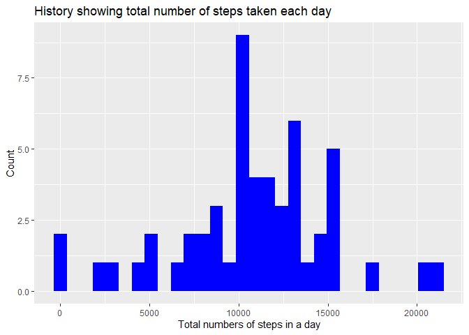

```r
Totalactivity %>%
ggplot(mapping = aes(x = totalsteps)) +
  geom_histogram(fill = "blue")+
  labs(x ="Total numbers of steps in a day", y="Count")+
  ggtitle("History showing total number of steps taken each day")
```

- Mean and median total number of steps taken per day across the two month period is calculated below.

```r
Totalactivity %>%
  summarise(meansteps = mean(totalsteps), mediansteps = median(totalsteps))
```

```
## # A tibble: 1 x 2
##   meansteps mediansteps
##       <dbl>       <dbl>
## 1    10766.       10765
```

The mean total number of steps per day was 10766 and the median total number of steps per day was 10765.

## What is the average daily activity pattern?

- Time series plot of the 5-minute interval and the average number of steps taken.

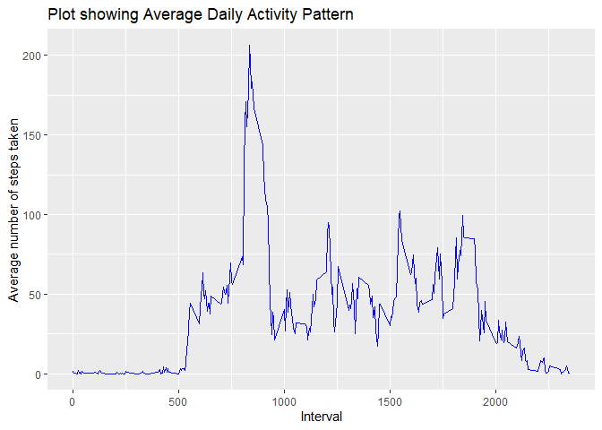

```r
activity %>%
  group_by(interval) %>%
summarise(avgsteps = mean(steps, na.rm = TRUE)) %>%
  ggplot(mapping = aes(x=interval, y=avgsteps))+
  geom_line(color="blue", size=0.7)+
  labs(x ="Interval", y="Average number of steps taken")+
  ggtitle("Plot showing Average Daily Activity Pattern")
```

- The 5-minute interval, on average across all the days in the dataset, containing the maximum number of steps.

```r
activity %>%
  group_by(interval) %>%
summarise(avgsteps = mean(steps, na.rm = TRUE)) %>%
            arrange(desc(avgsteps))
```

```
## # A tibble: 288 x 2
##    interval avgsteps
##       <dbl>    <dbl>
##  1      835     206.
##  2      840     196.
##  3      850     183.
##  4      845     180.
##  5      830     177.
##  6      820     171.
##  7      855     167.
##  8      815     158.
##  9      825     155.
## 10      900     143.
## # ... with 278 more rows
```

From the above, the 5-minute interval on average across all the days in the dataset, containing the maximum number of steps is the 835 interval.

## Imputing missing values

- Total number of missing values in the dataset

```r
summary(activity)
```

```
##      steps             date               interval
##  Min.   :  0.00   Min.   :2012-10-01   Min.   :   0.0
##  1st Qu.:  0.00   1st Qu.:2012-10-16   1st Qu.: 588.8
##  Median :  0.00   Median :2012-10-31   Median :1177.5
##  Mean   : 37.38   Mean   :2012-10-31   Mean   :1177.5
##  3rd Qu.: 12.00   3rd Qu.:2012-11-15   3rd Qu.:1766.2
##  Max.   :806.00   Max.   :2012-11-30   Max.   :2355.0
##  NA's   :2304
```

The total number of rows with NAs are found in the steps field only and as seen as above consist of 2304 rows.

- Strategy for filling in all of the missing values in the dataset.

```r
imputedvalues<- activity %>%
  filter(!is.na(steps)) %>%
  group_by(interval) %>%
summarise(avgsteps = mean(steps))
```

Assuming that the data are missing completely at random, mean imputation is the chosen method for filling in the missing values. The mean of each 5-minute intervals has been calculated above and NAs will be replaced by the corresponding mean.

- New dataset that is equal to the original dataset but with the missing data filled in.

```r
activitynew <- left_join(x = activity, y = imputedvalues, by = "interval") %>%
  mutate(steps = ifelse(is.na(steps),avgsteps,steps))
```

- Histogram showing total number of steps taken each day for new dataset with imputed missing values

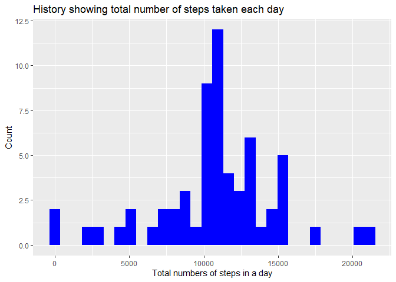

```r
activitynew %>%
  group_by(date) %>%
  summarise(totalsteps=sum(steps)) %>%
ggplot(mapping = aes(x = totalsteps)) +
  geom_histogram(fill = "blue")+
  labs(x ="Total numbers of steps in a day", y="Count")+
  ggtitle("History showing total number of steps taken each day")
```

- Mean and median total number of steps taken per day across the two month period is calculated below using new dataset with imputed missing values.

```r
activitynew %>%
  group_by(date) %>%
  summarise(totalsteps=sum(steps))%>%
  summarise(meansteps = mean(totalsteps), mediansteps = median(totalsteps))
```

```
## # A tibble: 1 x 2
##   meansteps mediansteps
##       <dbl>       <dbl>
## 1    10766.      10766.
```

The imputation of missing values using mean intervals does not appear to have much impact on the estimates for mean and median total number of daily steps. The mean total number of steps remained the same and the median number of steps only differ by one. It should be noted that the chosen method above is not very sophisticated and indeed perhaps another sophisticated method would probably have greater impact. Additionally, the method above assumes that the data is missing completely at random and if this assumption is false, biased estimates can result.

## Are there differences in activity patterns between weekdays and weekends?